# MIS 306 Data Analysis | Competition

# Statistical Tests

## Kolmogorov-Smirnov Test

This Kolmogorov-Smirnov test compares the return distributions of Mondays and Tuesdays. The test statistic is `D = 0.067225`, and the p-value is `0.03324`. Since the p-value is below 0.05, the result is statistically significant. This means there is evidence that the return distributions for Mondays and Tuesdays are different, suggesting that returns behave differently on these two weekdays.

```
##
##  Asymptotic two-sample Kolmogorov-Smirnov test
##
## data:  NKE_AD.ret[wday(index(NKE_AD.ret)) == 2] and NKE_AD.ret[wday(index(NKE_AD.ret)) == 3]
## D = 0.067225, p-value = 0.03324
## alternative hypothesis: two-sided
```

```
##
##  Asymptotic two-sample Kolmogorov-Smirnov test
##
## data:  NKE_AD.ret[wday(index(NKE_AD.ret)) == 2] and NKE_AD.ret[wday(index(NKE_AD.ret)) == 6]
## D = 0.047027, p-value = 0.2747
## alternative hypothesis: two-sided
```

## Time Series Decomposition

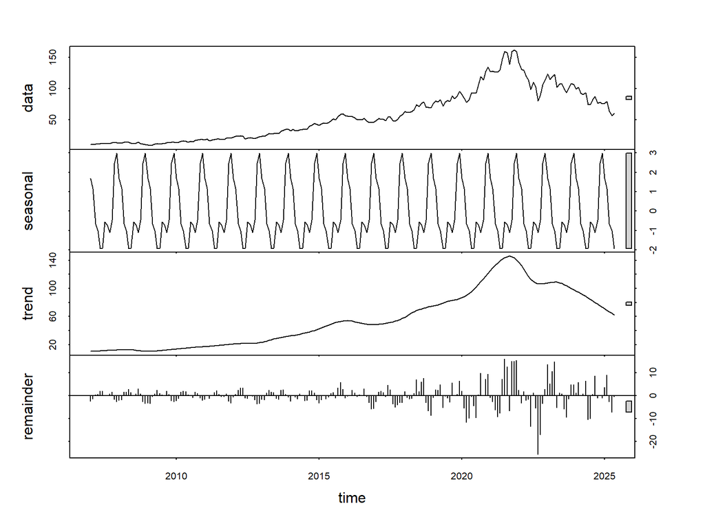

This plot shows the decomposition of Nike’s monthly adjusted prices into four parts: data, seasonal, trend, and remainder. The data panel shows the original price movement, with growth until 2021, followed by a decline. The seasonal panel reveals repeating yearly patterns, showing that seasonality exists in the data. The trend panel shows long-term growth peaking around 2021, then dropping. The remainder shows random noise or irregular movements. Overall, the stock price is influenced by both seasonality and long-term trends.

## Forecasting

Since we both have trend and seasonality in our data we will use Holt Winter’s Forecast Method.

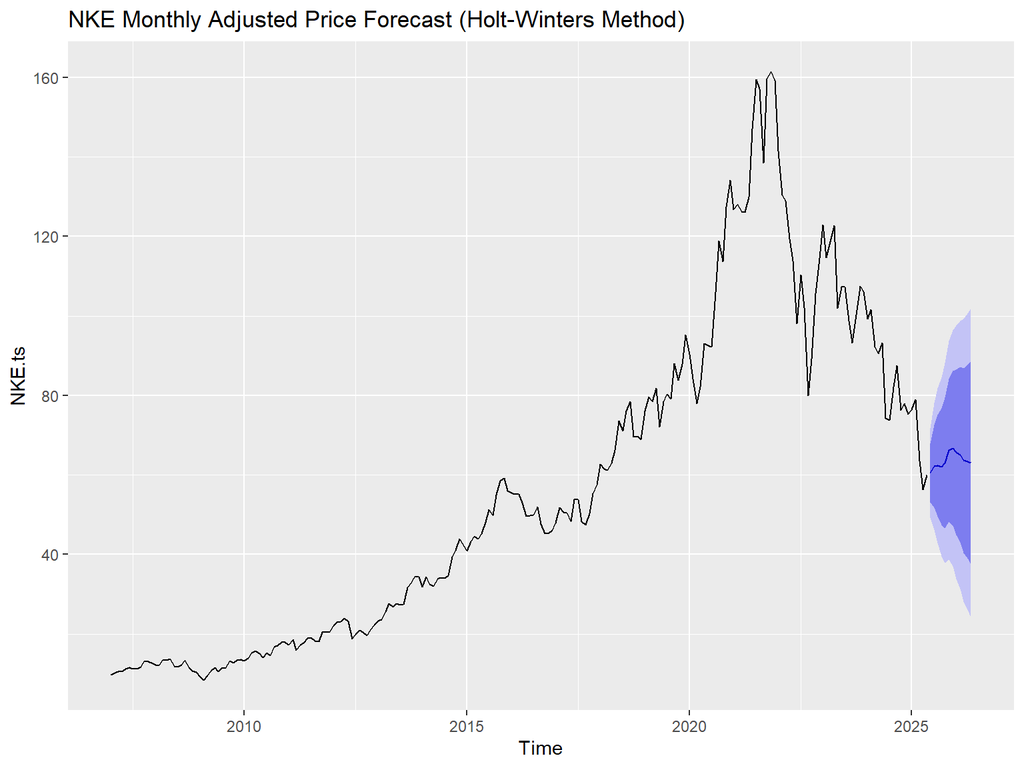

This chart shows the forecast of Nike’s monthly adjusted prices using the Holt-Winters method. The black line represents historical prices, which rose sharply until 2021 and then declined. The blue line shows the forecast for the next 12 months, while the shaded area indicates the confidence intervals. The forecast suggests a slight upward trend, but the wide shaded area shows there is uncertainty. Overall, the model expects possible recovery, but with some risk.

```
## ETS(A,A,A)
##
## Call:
## ets(y = NKE.ts, model = "AAA")
##
##   Smoothing parameters:
##     alpha = 0.9982
##     beta  = 1e-04
##     gamma = 1e-04
##
##   Initial states:
##     l = 11.1381
##     b = 0.2539
##     s = 2.9034 2.6675 -0.262 -0.9554 -0.4081 -0.3523
##            -1.7874 -2.0203 -1.4172 -0.8658 0.8161 1.6814
##
##   sigma:  5.7403
##
##      AIC     AICc      BIC
## 1982.787 1985.802 2040.556
##
## Training set error measures:
##                       ME     RMSE      MAE        MPE     MAPE      MASE
## Training set -0.02541288 5.528622 3.583211 -0.3568962 7.033724 0.2748074
##                     ACF1
## Training set 0.003479613
```

# Smoothing

## Adjusted Close

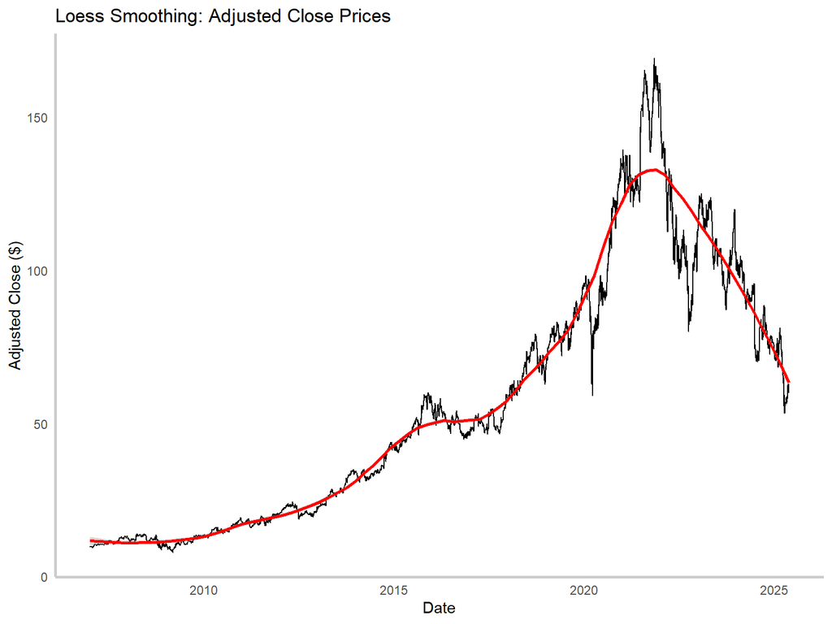

## High Prices

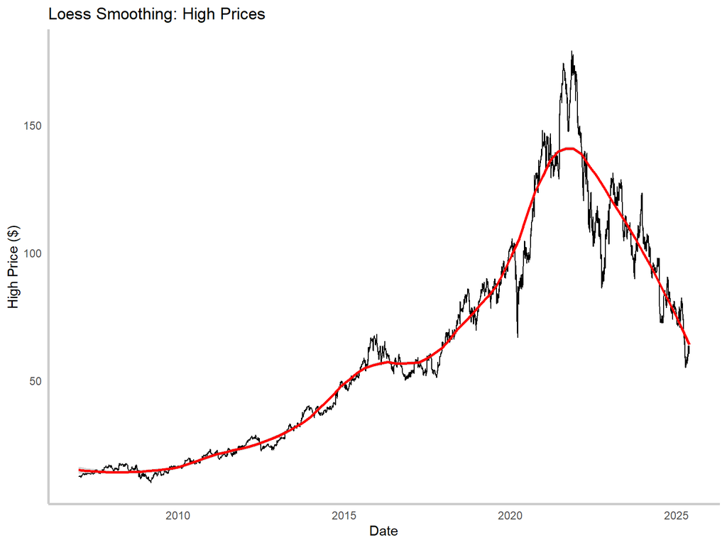

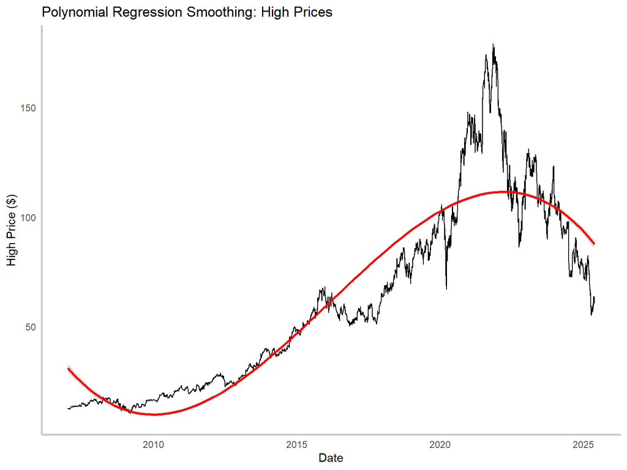

These charts show Nike’s high stock prices over time, using two different smoothing methods.

- The first chart uses Loess smoothing. The black line shows the actual high prices, while the red line reveals a smooth trend. It clearly shows a steady increase until 2021, followed by a noticeable decline. This method captures short-term movements while showing the overall trend.
- The second chart uses polynomial regression smoothing. The red line is smoother and more general. It shows a slow rise from 2010 to 2021, then a decline, but it doesn’t follow the short-term fluctuations as closely.

Overall, both methods show a long-term rise and fall in prices, but Loess gives a more detailed view, while polynomial regression gives a broader trend.

## Low Prices

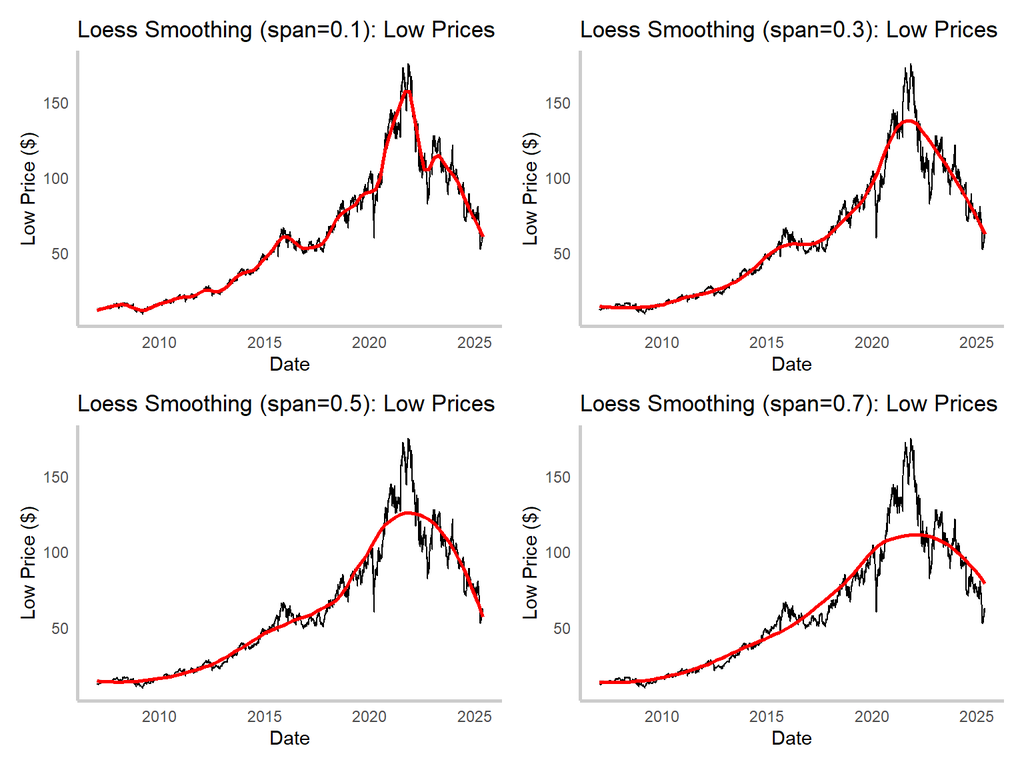

This chart compares Loess smoothing with different span values applied to Nike’s low prices. The black lines show actual prices, and red lines show smoothed trends. With span = 0.1, the red line closely follows the data, showing more detail. As the span increases to 0.3, 0.5, and 0.7, the red line becomes smoother and less sensitive to short-term changes. Larger spans highlight the overall trend better, while smaller spans capture more local fluctuations. Overall, the choice of span affects how much of the short-term movement is shown in the trend.

# ARMA & ARIMA

## Stationarity Testing and Autocorrelation Analysis

The ADF test shows Nike’s stock prices are not stable over time (Dickey-Fuller = -0.43, p-value = 0.99). This means the prices follow trends that change. Since the test says we need to difference the data once (ndiffs() = 1), we should calculate daily price changes. After this change, we can check again if the data becomes stable. This step is important before using ARIMA models, which need stable data to work properly. The very high p-value proves the prices need this adjustment.

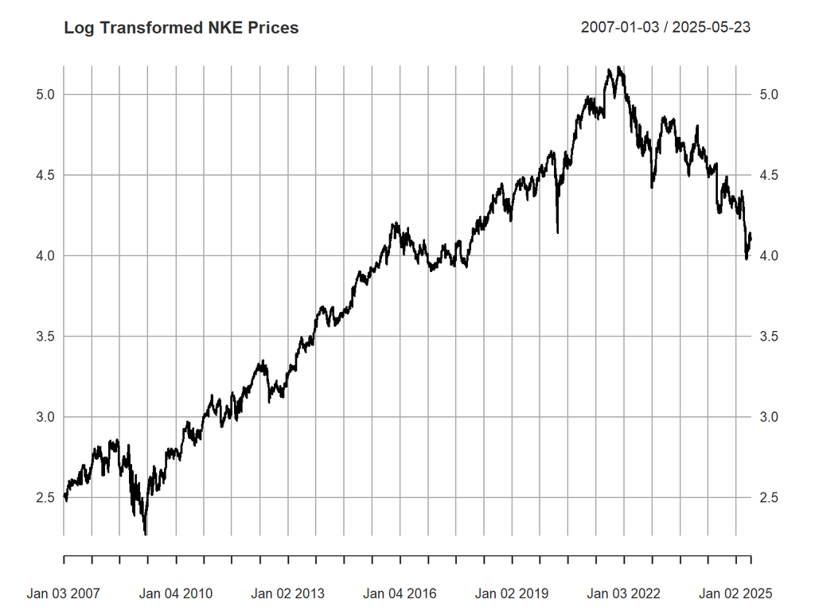

```
##
##  Augmented Dickey-Fuller Test
##
## data:  as.numeric(nke_close)
## Dickey-Fuller = -0.42659, Lag order = 16, p-value = 0.9852
## alternative hypothesis: stationary
```

```
## [1] 1
```

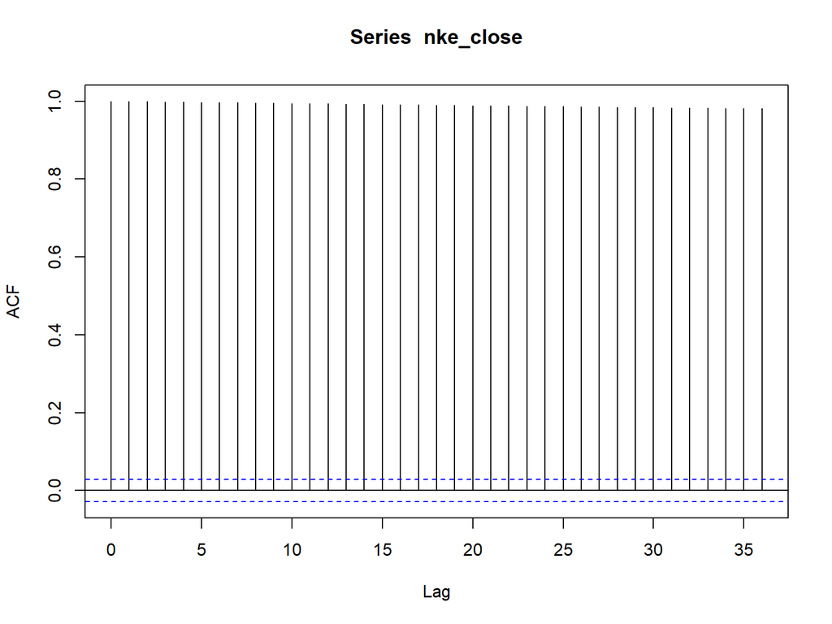

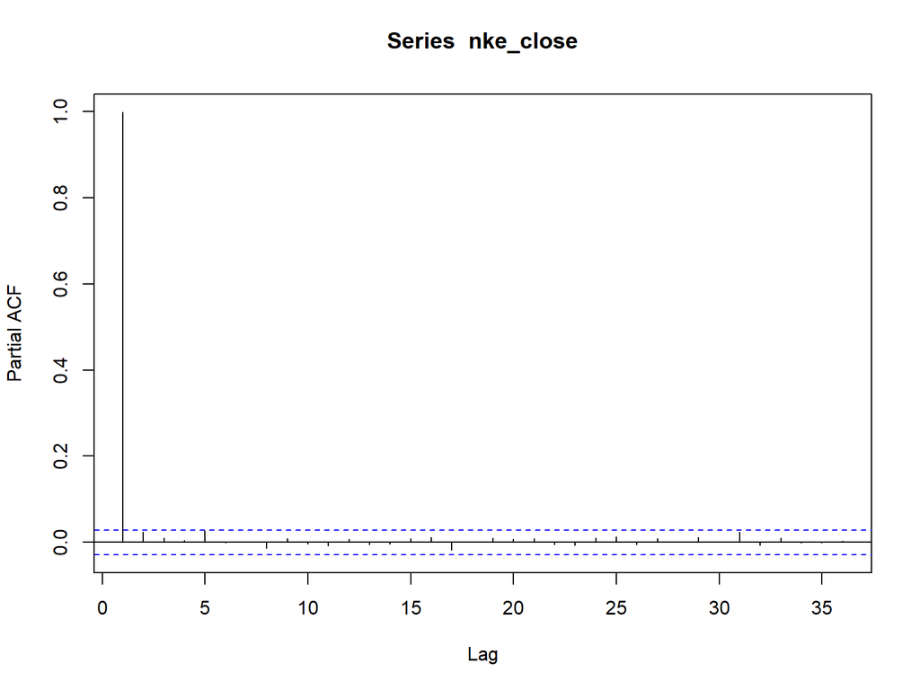

The log-transformed NKE prices graph shows the stock’s price movement from 2007 to 2025. The upward trend until 2021 indicates strong growth, followed by a recent decline. This long-term pattern suggests the data needs differencing to remove trends before analysis.

The ACF (Autocorrelation Function) plot reveals how prices correlate with their past values. The gradual decline in correlation values across lags confirms the presence of trends, supporting the need for differencing to achieve stationarity.

The PACF (Partial Autocorrelation Function) plot identifies direct relationships between current prices and specific past prices. The significant spike only at lag 1 suggests an AR(1) component might be appropriate when modeling the differenced series. Together, these plots confirm the non-stationary nature of the data and guide appropriate model selection.